# White Wines by Victor Jaen

This data set contains several metrics about white wines and a qualitative variable that contains the evaluation of the whine by experts. So right from the start most of the analysis will be oriented in trying to identify what variables are the most important predictor in wine quality. Besides this we will be exploring if within this variable, some relationship exist and hypothesize why this could be.

# Univariate Plots Section

```
##   X fixed.acidity volatile.acidity citric.acid residual.sugar chlorides
## 1 1           7.0             0.27        0.36           20.7     0.045
## 2 2           6.3             0.30        0.34            1.6     0.049
## 3 3           8.1             0.28        0.40            6.9     0.050
## 4 4           7.2             0.23        0.32            8.5     0.058
## 5 5           7.2             0.23        0.32            8.5     0.058
## 6 6           8.1             0.28        0.40            6.9     0.050
##   free.sulfur.dioxide total.sulfur.dioxide density   pH sulphates alcohol
## 1                  45                  170  1.0010 3.00      0.45     8.8
## 2                  14                  132  0.9940 3.30      0.49     9.5
## 3                  30                   97  0.9951 3.26      0.44    10.1
## 4                  47                  186  0.9956 3.19      0.40     9.9
## 5                  47                  186  0.9956 3.19      0.40     9.9
## 6                  30                   97  0.9951 3.26      0.44    10.1
##   quality
## 1       6
## 2       6
## 3       6
## 4       6
## 5       6
## 6       6
```

First I print the head of the data set to have a quick glance.

```
##        X        fixed.acidity    volatile.acidity  citric.acid
##  Min.   :   1   Min.   : 3.800   Min.   :0.0800   Min.   :0.0000
##  1st Qu.:1225   1st Qu.: 6.300   1st Qu.:0.2100   1st Qu.:0.2700
##  Median :2450   Median : 6.800   Median :0.2600   Median :0.3200
##  Mean   :2450   Mean   : 6.855   Mean   :0.2782   Mean   :0.3342
##  3rd Qu.:3674   3rd Qu.: 7.300   3rd Qu.:0.3200   3rd Qu.:0.3900
##  Max.   :4898   Max.   :14.200   Max.   :1.1000   Max.   :1.6600
##  residual.sugar     chlorides       free.sulfur.dioxide
##  Min.   : 0.600   Min.   :0.00900   Min.   :  2.00
##  1st Qu.: 1.700   1st Qu.:0.03600   1st Qu.: 23.00
##  Median : 5.200   Median :0.04300   Median : 34.00
##  Mean   : 6.391   Mean   :0.04577   Mean   : 35.31
##  3rd Qu.: 9.900   3rd Qu.:0.05000   3rd Qu.: 46.00
##  Max.   :65.800   Max.   :0.34600   Max.   :289.00
##  total.sulfur.dioxide    density             pH          sulphates
##  Min.   :  9.0        Min.   :0.9871   Min.   :2.720   Min.   :0.2200
##  1st Qu.:108.0        1st Qu.:0.9917   1st Qu.:3.090   1st Qu.:0.4100
##  Median :134.0        Median :0.9937   Median :3.180   Median :0.4700
##  Mean   :138.4        Mean   :0.9940   Mean   :3.188   Mean   :0.4898
##  3rd Qu.:167.0        3rd Qu.:0.9961   3rd Qu.:3.280   3rd Qu.:0.5500
##  Max.   :440.0        Max.   :1.0390   Max.   :3.820   Max.   :1.0800
##     alcohol         quality
##  Min.   : 8.00   Min.   :3.000
##  1st Qu.: 9.50   1st Qu.:5.000
##  Median :10.40   Median :6.000
##  Mean   :10.51   Mean   :5.878
##  3rd Qu.:11.40   3rd Qu.:6.000
##  Max.   :14.20   Max.   :9.000
```

We can see that all variables are numerical, and I will probably use them as they are. If the need for a categorical one arises I will create it down the line. The other observation is that they have very different ranges and distributions which is expected given the variety of data we have here. All variables seem to be continuous, except for quality, which seems discrete.

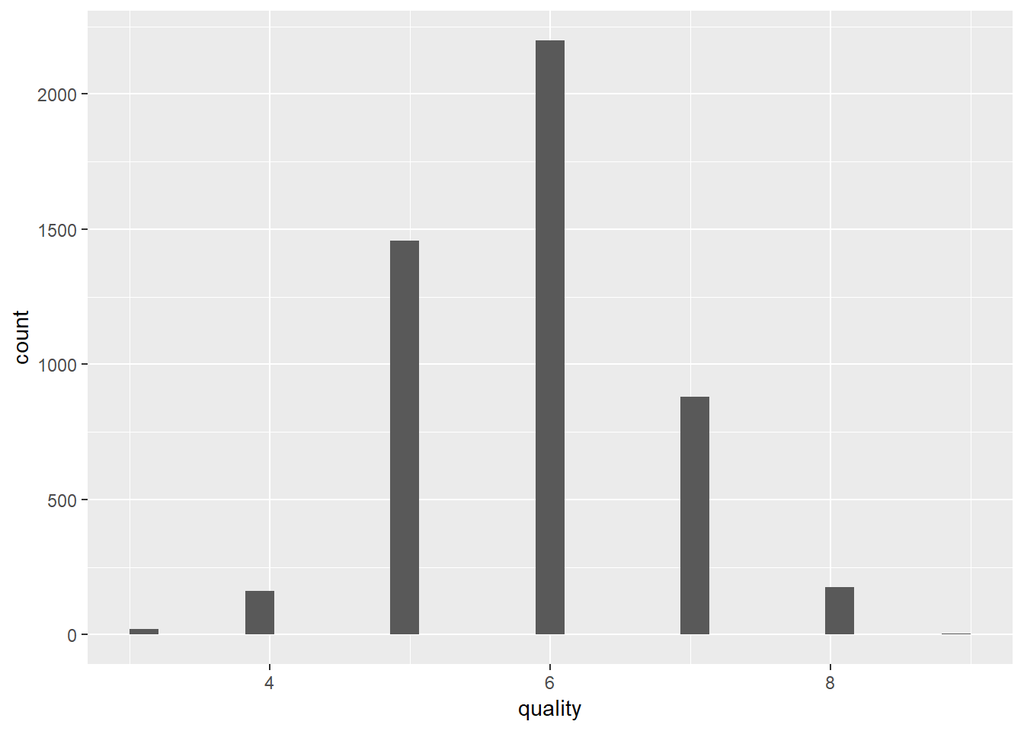

I was first interested in quality. The variable is discrete, but this is expected since the evaluation was given from a discrete range. I will create an additional variable which will divide the wine in bad, average, and good based on the quality. The ranges will be from 0 to 4, 5 to 7 and then 8 to 10 respectively.

```
##
## average     bad    good
##    4535     183     180
```

The majority of the wines are average as shown in the histogram. This will help in plotting downstream.

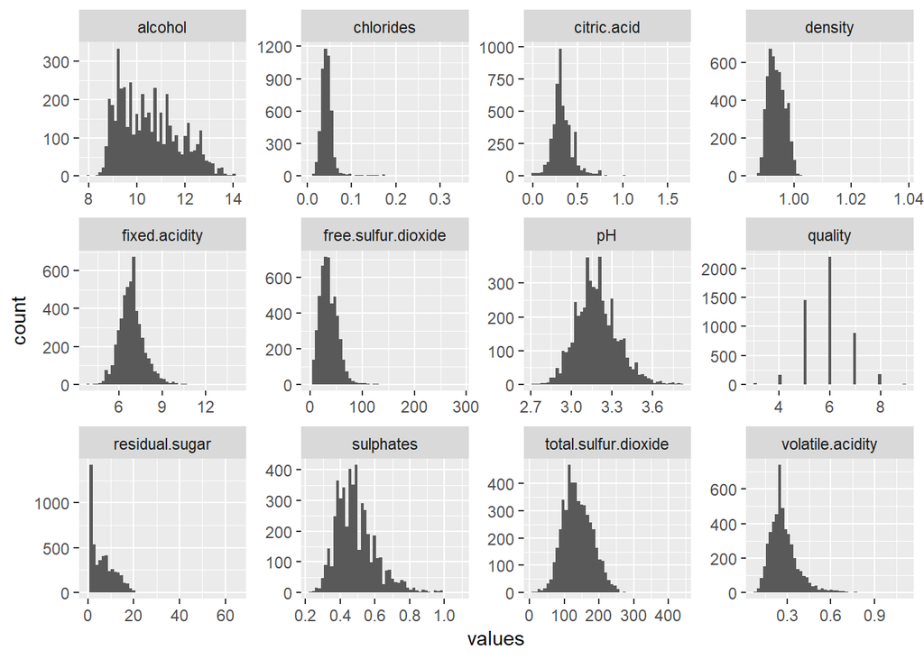

```r
#To create a tidy dataset we use the gather function.
df_tidy <- df %>% select(-quality_group) %>% gather(key,values,fixed.acidity,volatile.acidity, citric.acid,
                        residual.sugar,chlorides,free.sulfur.dioxide,
                        total.sulfur.dioxide,density,pH,sulphates,alcohol,
                        quality)

df_tidy %>% ggplot(aes(x=values)) + geom_histogram(bins = 50) + facet_wrap(~key, scales= "free")
```

I wanted to have quick distribution of all variables. So using the gather function from tidy verse, I created a tidy data set to make the use of ggplot easier.Most of the variables seem to be normally distributed. They had different spreads and a little bit of skewness, but most seem pretty central. I will take a further look on a couple of variables that I think need closer examination.

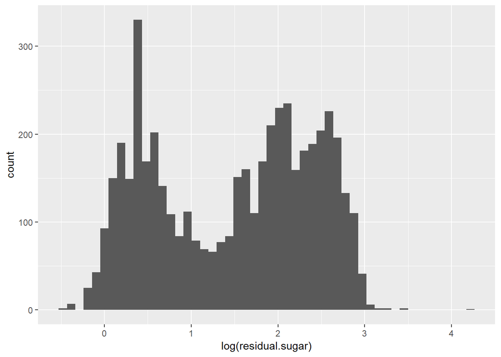

Residual sugar was very skewed to one side. Using a logarithmic scale we can see actually almost two distributions with peaks around 0.5 and 2. We are going to have a closer look to this phenomena in the coming sections.

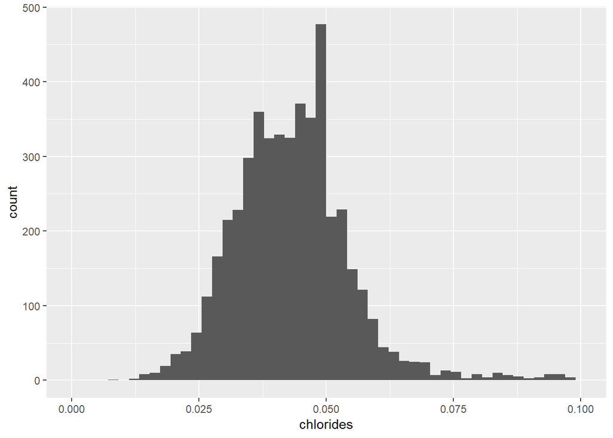

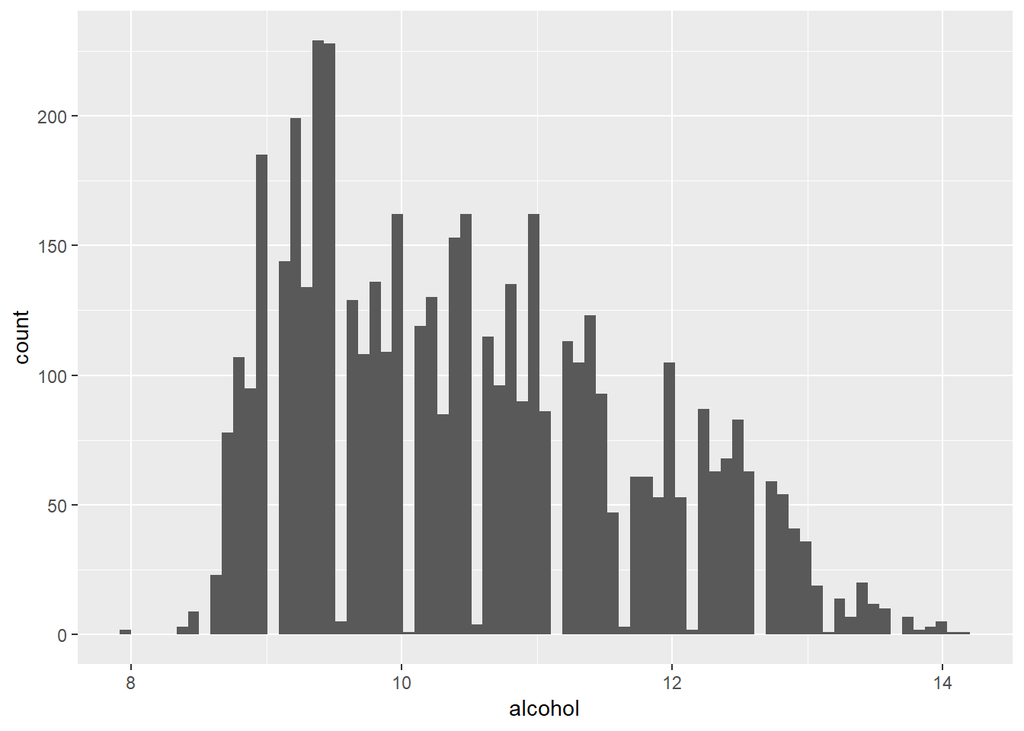

The alcohol variable shows are sort of discrete behavior. It seems that the variable simply is missing some specific values, they are randomly distributed. Thinking why this could be my guess is a function of the chemical test done to measure this variable or the instruments used.

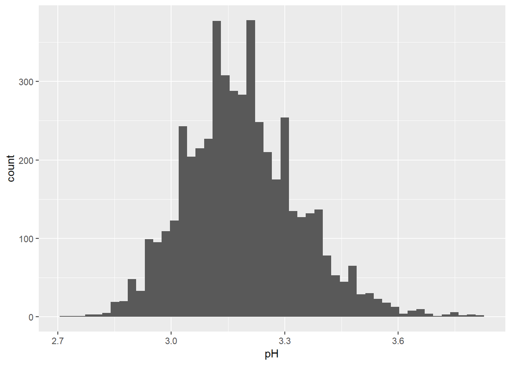

```r
df %>% ggplot(aes(x=pH)) + geom_histogram(bins = 50)
```

Observing pH now that shows a couple of different peaks but still is normally distrubted around 3.15 pH with two medians.

# Univariate Analysis

### What is the structure of your dataset?

Is mostly of numeric variables, most of them seem to be normally distrbuted with different spreads.

### What is/are the main feature(s) of interest in your dataset?

If this uniformity is represented with looking a two variables simultaneously Is there any sweet spot in this variables explained in good wine quality.

### What other features in the dataset do you think will help support your #investigation into your feature(s) of interest?

All the other variables. At this stage is to early to disregard any variable.

### Did you create any new variables from existing variables in the dataset?

Yes. I created a factor variable called quality groups that divides the wine in three main categories: bad, average and good. This will help identify better trends in the following plots.

### Of the features you investigated, were there any unusual distributions? Not really. Only the residual sugar, a little bit skewed but with a logarithmic

transformation, we saw that there seems to be two different distributions for that variable.

### Did you perform any operations on the data to tidy, adjust, or change the form ### of the data? If so, why did you do this?

I created a tidy data set to leverage facet_wrap from ggplot and generate all the distributions in one line. This tidy data set is call df_tidy. Depending on the need I will point out if I need to use it in other plots, however most of the analysis will be done on the main one.

# Bivariate Plots Section

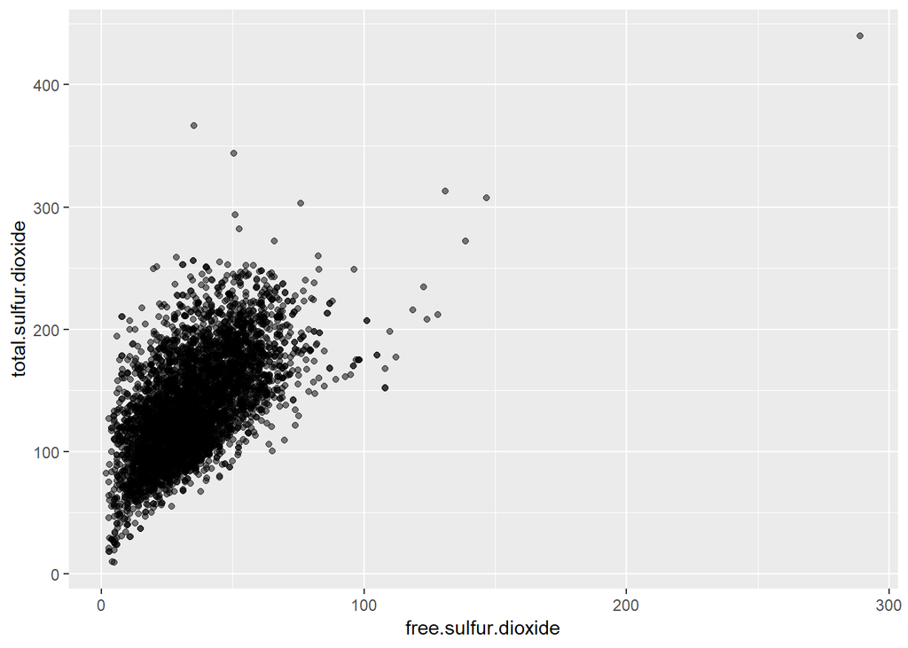

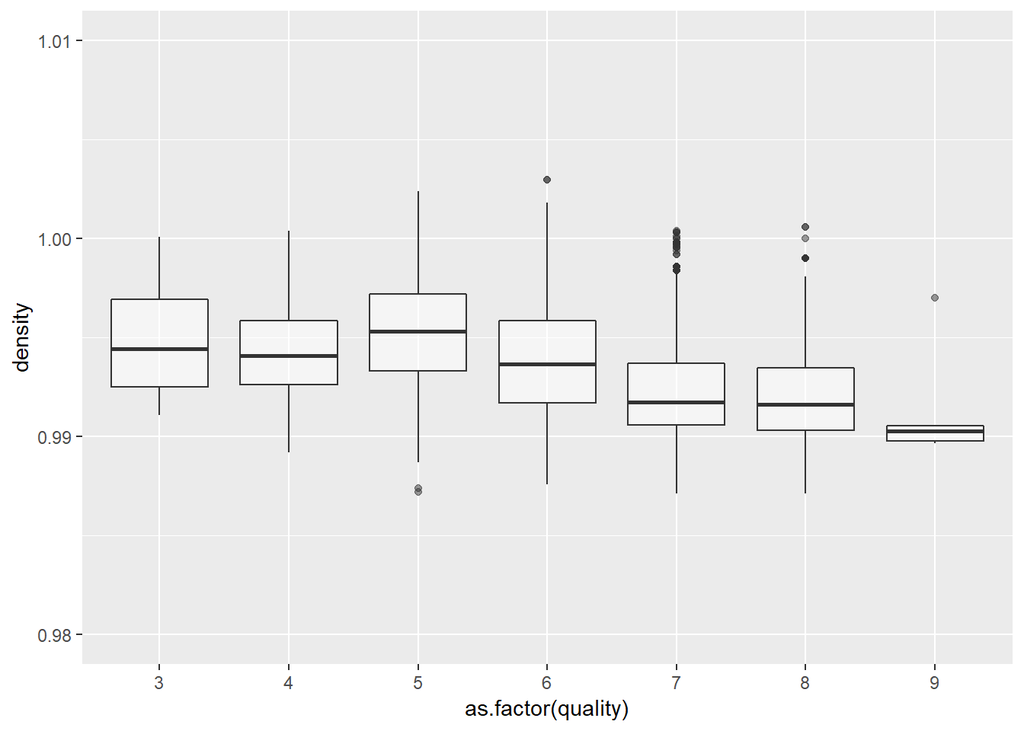

It seems that the “better” wines have lower density, given the similarity of the 7 and 8 quality. Im cautious with the 9 boxplot, since it could be the result of less samples rather than an actual pattern. Just to confirm if this is the case, I will replicate the graph using the quality_group variable created before.

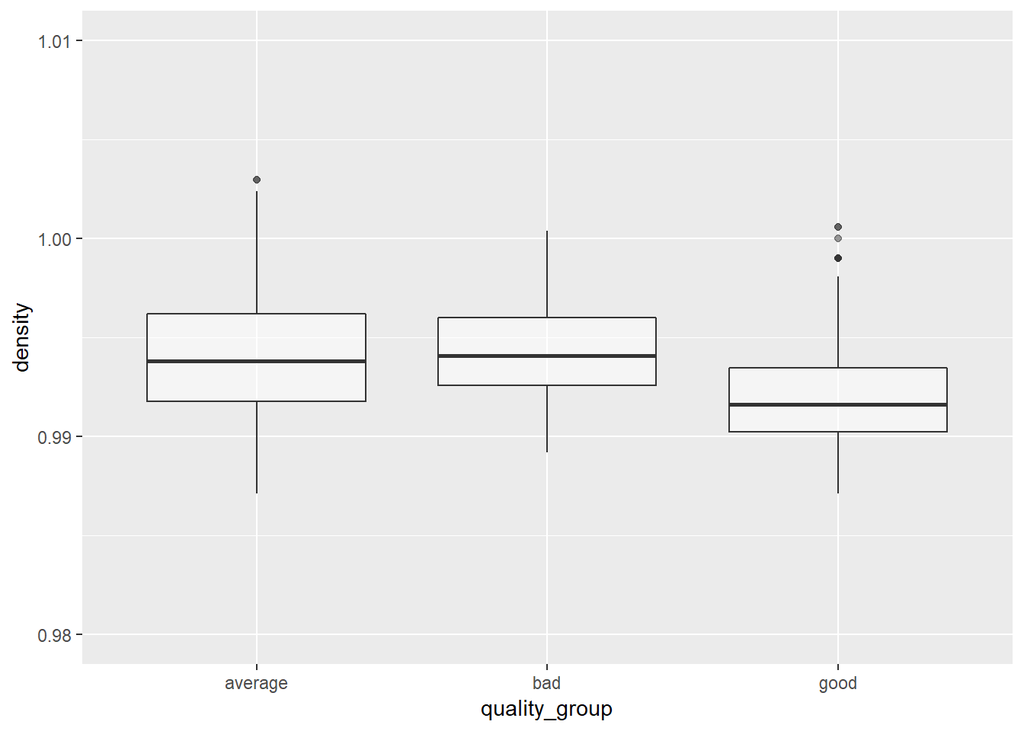

Yes, it seems that good wines have lower density than other ones. An important thing is that this could be result of sample size, there are less good quality wines, hence the distribution is more uniform.

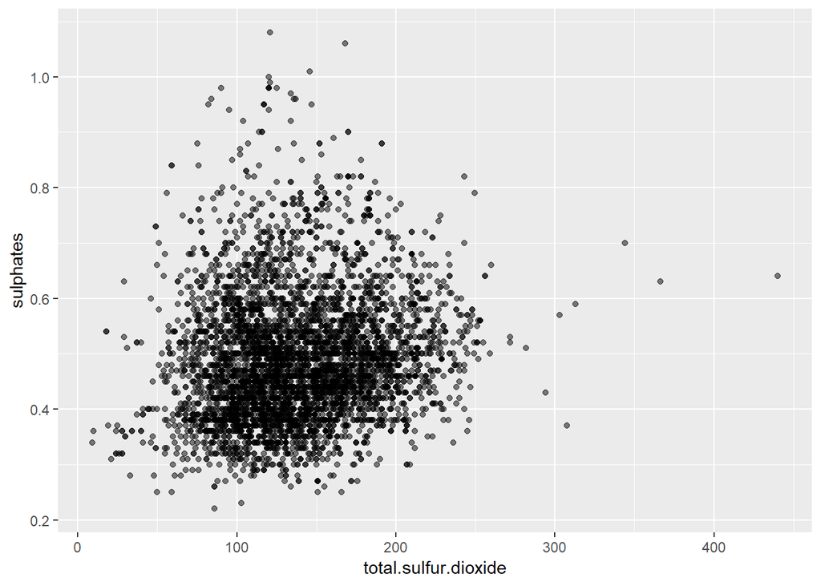

Looking at other variables, I was curious if total sulfur dioxide had some relationship with Sulphates. In this graphs there seems to be a very weak correlation, at least weaker than I expected. (I know chemically they are different compounds, but they should have some relationship)

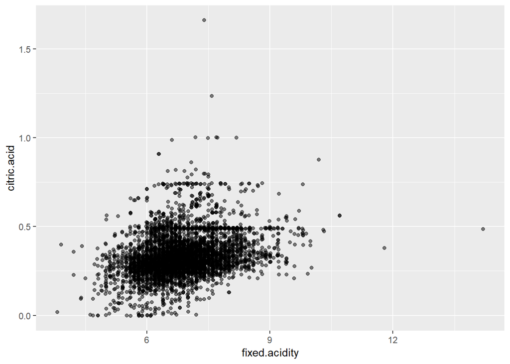

Looking at the acidity variables, there seems to be some relationship between the citric acid and the fixed acidity. Chemically Im not sure what could be the mechanism happening behind but this seems to be expected. Source (https://www.winespectator.com/drvinny/show/id/Difference-Between-Sulfites-Sulfates-Wine-54706)

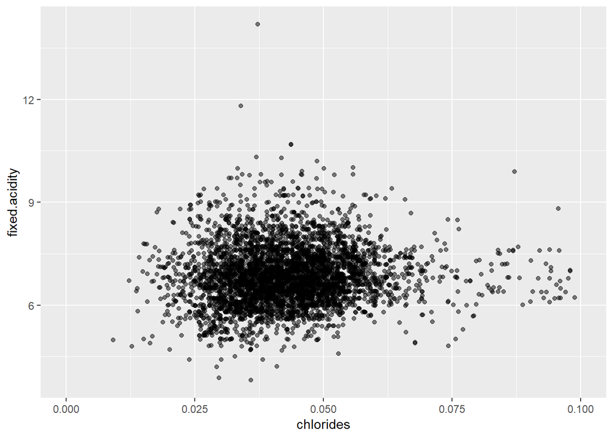

Exploring othe variables, chlorides does not seem to have any relation with fixed acidity.

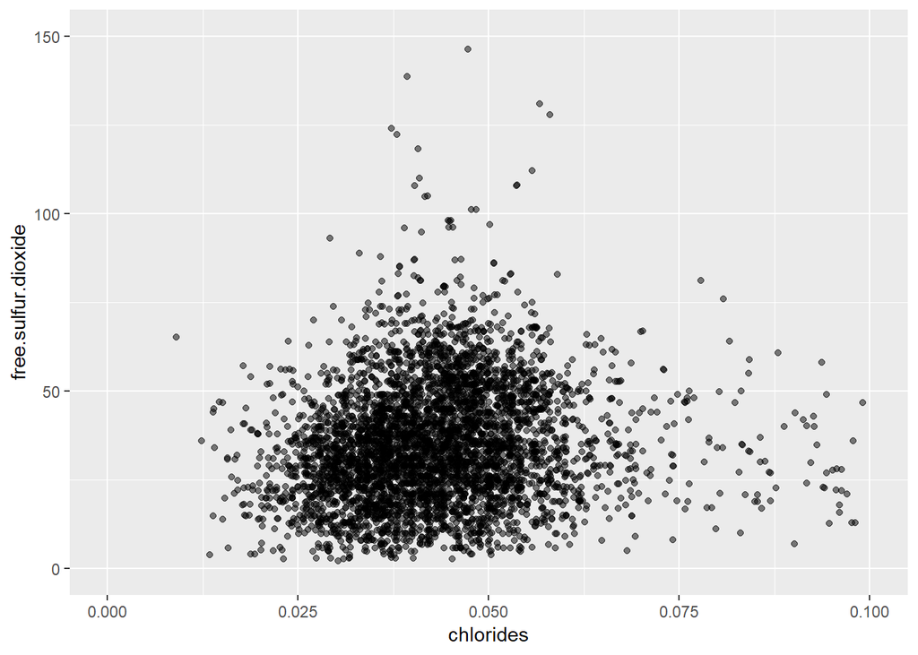

Similar as the previous graph, there is not much going on between chlorides and free sulfur dioxide.

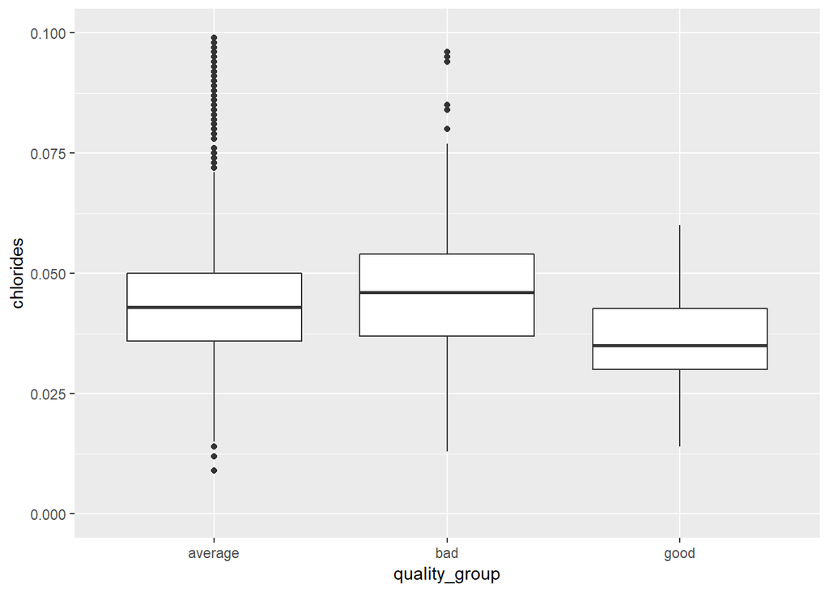

If chlorides are not showing any pattern with other variables I thought it might worth to compare it to the output variable. And indeed as density it seems to be a pattern with good wines having lower chlorides levels.

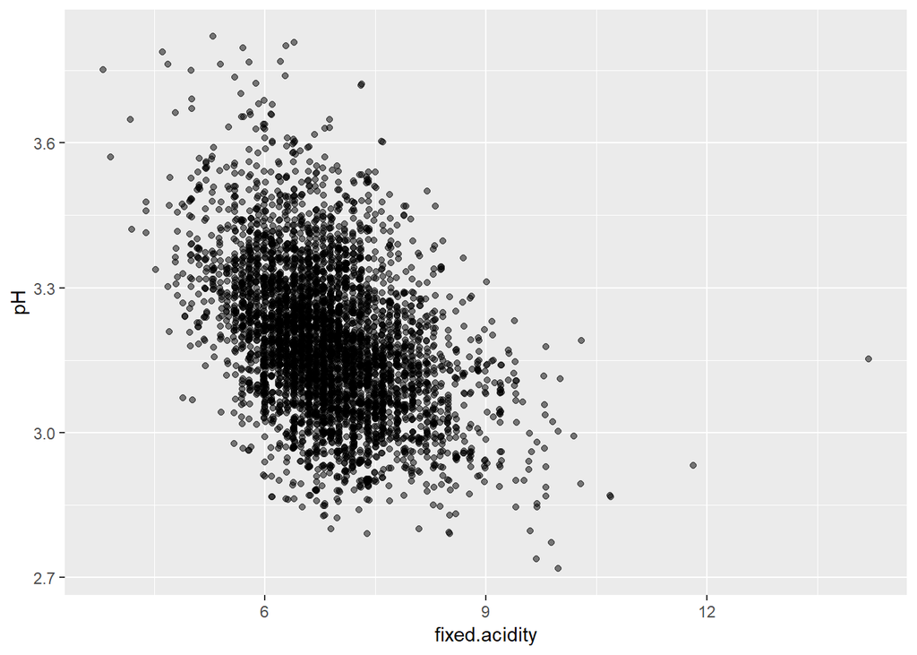

Continuing exploring different variables from the output, I wanted to confirm the relationship between pH an acidity. From This graph we can show that there s a decent relationship.

```
## [1] -0.4258583
```

Running the correlation function we see that the value is actually rather low, -0.42. Possibly some outliers are impacting this value.

# Bivariate Analysis

### Talk about some of the relationships you observed in this part of the investigation. How did the feature(s) of interest vary with other features in the dataset?

I didnt want to focus solely on the quality variable and its relationship with other ones. Altough I recognize this may be the most important thing to do. Having said that, I picked density to see if it showed some relationship and it seems it does. Good wines have a lower density distribution than the other wines.

### Did you observe any interesting relationships between the other features

The acidity variables seems to have some relationship. However the sulfate and sulphates variables does not seem to be related. Chlorides didn’t show relationship with other variables.

### What was the strongest relationship you found?

Density seems to have an inverse relationship with wine quality. Good wines, above 7, have lower densities than the average and bad wines. Chlorides also seem to show strong relationship with quality.

# Multivariate Plots Section

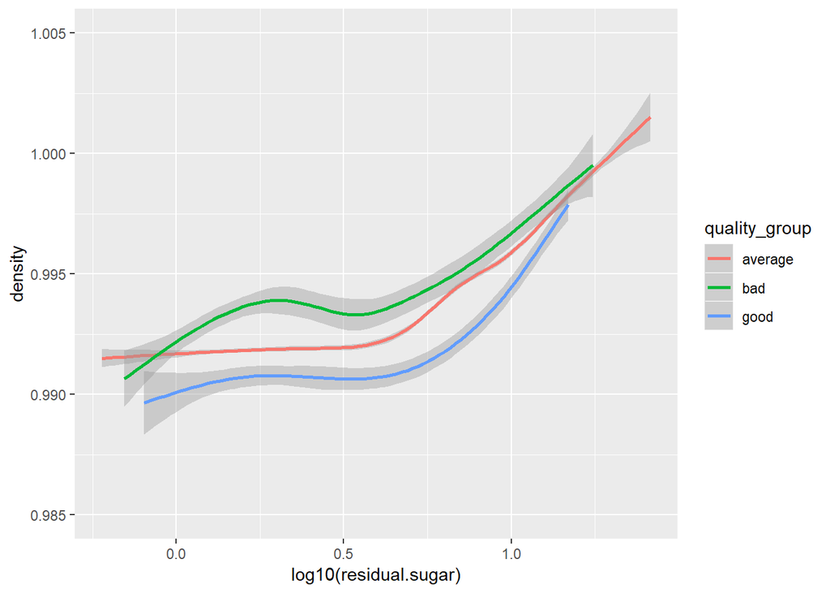

I was first curios about residual sugar and density since both showed some sort of different relationship vs the rest of the variables. Using geom_smooth there seems to be some sort of proportional relationship between density and the log of residual sugar, and it seems similar across different wine groups. The fact that the average group goes farther is simply more variability within that group.

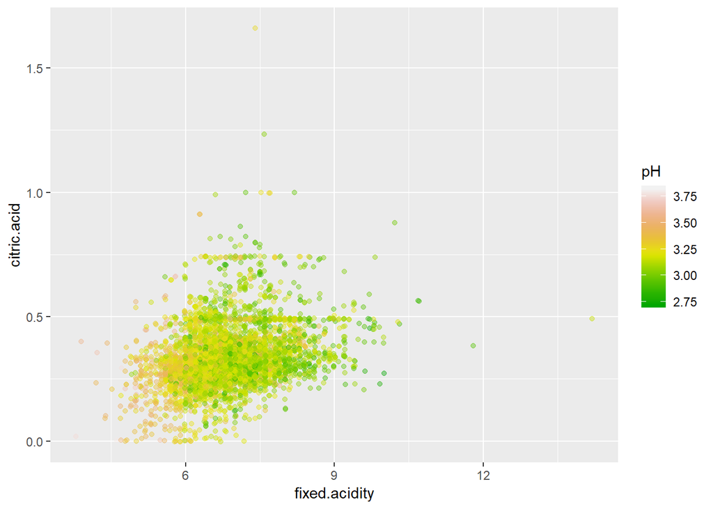

Also following up with pH, as expected there is a relationship between both acidities and pH. The higher the acidity de lower the pH. This may seem obvious however is always good to confirm in the dataset that the realworld phenonomenas hold true.

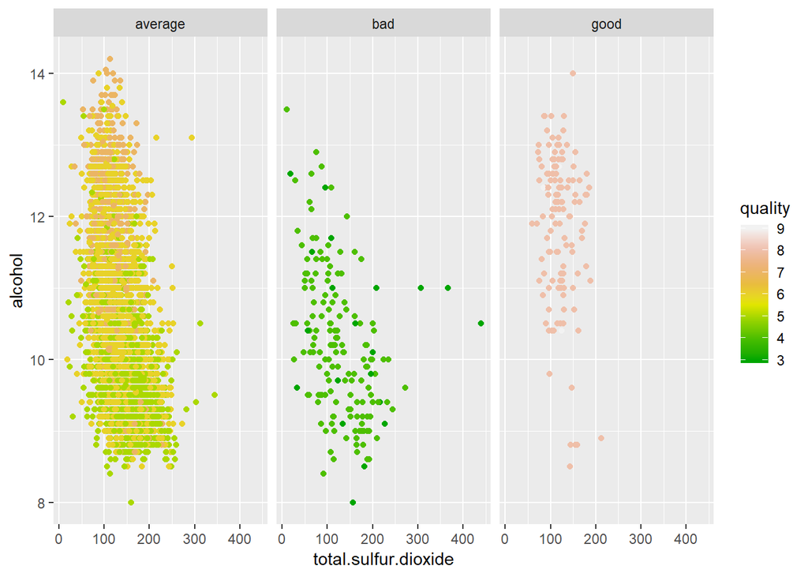

Also following up with the sulfur impact, I was interested in seeing it compared to alcohol. There does not seems to exist a relationship between alcohol and sulfur dioxide. Rather some sort of limitation, higher content wine seem to have no more than 200 of sulfur dioxide. On the quality side, high quality wines seem be concentrated in a narrower range of sulfur, a around above 10 of alchol content but besides does limit it could vary.

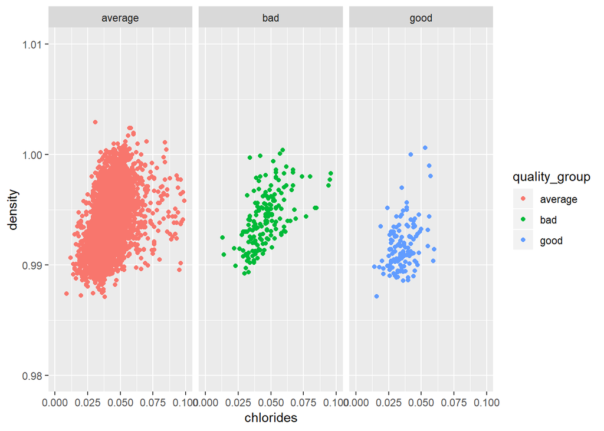

Closing up density and chlorides show a relationship between them relatively similar among quality groups.

# Multivariate Analysis

### Talk about some of the relationships you observed in this part of the investigation. Were there features that strengthened each other in terms of looking at your feature(s) of interest?

Alcohol, density, pH and chlorides seem to be the most important ones.

### Were there any interesting or surprising interactions between features?

Actually no. It seems very spread.

### OPTIONAL: Did you create any models with your dataset? Discuss the strengths and limitations of your model.

No model was created.

# Final Plots and Summary

### Plot One

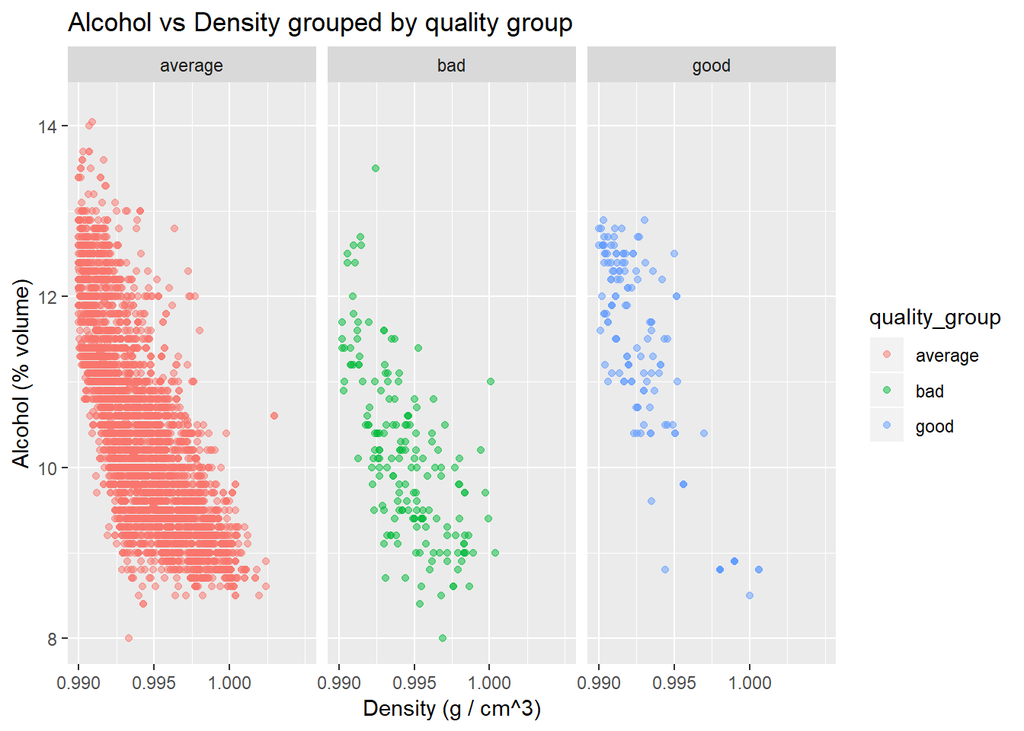

### Description One

Most good wines seem to have at least 10% alcohol by volume and have a narrower band of density between 0.99 g/cm^3 and 1 g/cm^3. For the other groups, the variability seems much broader. In other words, good wines seem to have some specific limits of density and alcohol. Another reason for this graph is to show the relationship between alcohol and density. The higher the alcohol content the lower the density, which makes sense because of the lower density of alcohol itself compared to water.

### Plot Two

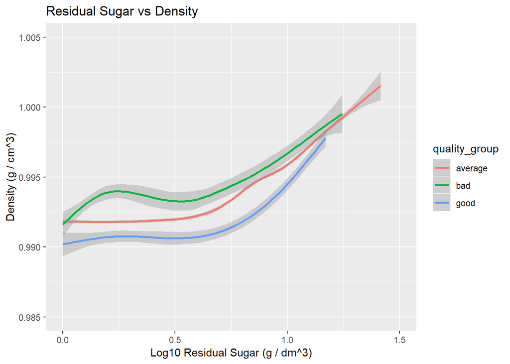

### Description Two

The residual sugars bimodal distribution got my attention before. This graphs shows how the residual sugar is related to density across all wine quality groups. However there does not seems to be a pattern that applies only to good quality wines when it comes to the residual sugar.

### Plot Three

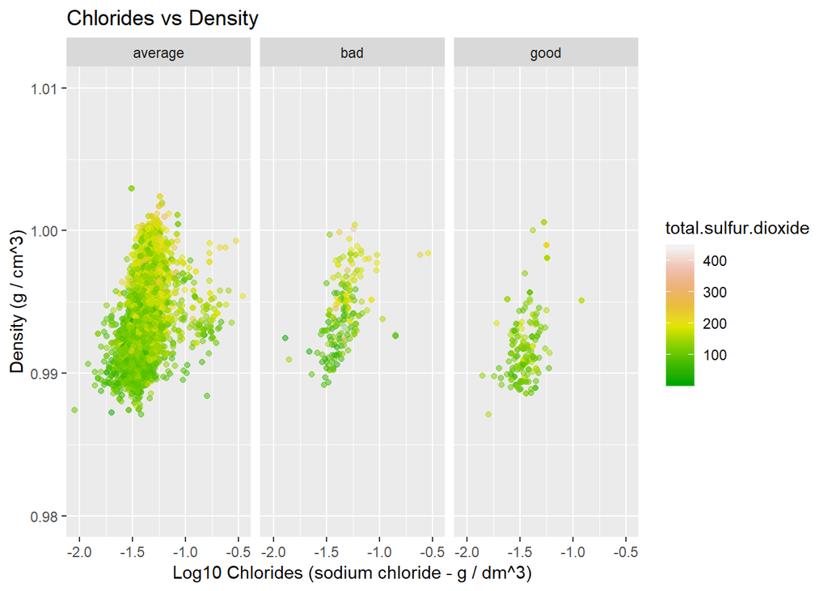

### Description Three

Finally chlorides, density and total sulfur signaled relationships across the analysis. This graph shows a certain pattern between the three. The higher the density and the chlorides content the higer the sulfur. Showing this behavior among the three quality groups we observe that the relationship holds true. We could very cautiously say that the better the group the less dispersion.

# Reflection

Exploring all variables directly with the output variable is not necessary the best path always. Understanding relationships between variables could help in feature selection, dropping variables that might not be interesting. After finishing the project I also realized the importance of creating a story. In this case was more organic than actually planned, but perhaps if beforehand I set some sort of structure the flow of graphs and analysis will probably be better and also for the reader will be easier to understand.

With exploratory analysis the possibilities are endless, being able to differ whats noise from what is actually important is the key, and is not that easy.